# Topic 8

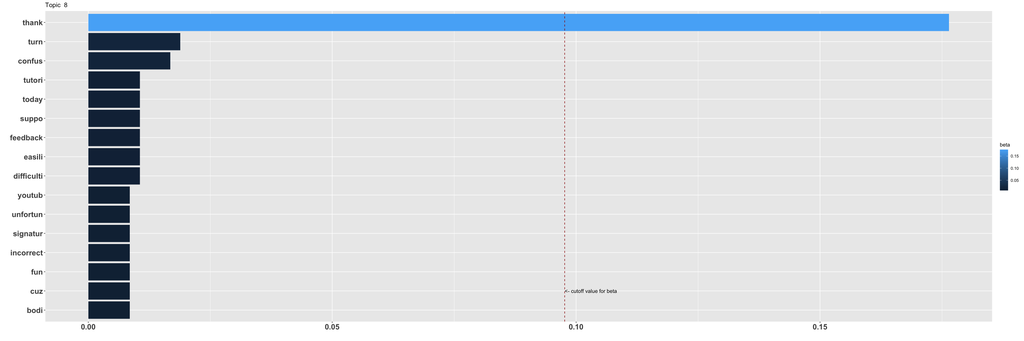

On interpreting beta: the term has a beta probability of being generated from the particular topic.

Values below are gamma : An estimated proportion of words from that document that are generated from that topic.

**Text Record Number: 75** gamma: 11 % likelihood of this document (based on its words) in this topic

**It does look good. The only thing I can think of is your weight distribution. Do you feel your weight go down through your sitting bones?

There is other things that you can’t gather from a picture. You need to be relaxed and feel free all the way through your arms and shoulders. Maybe a slight lean forward from where you are but not far.

I can’t see your feet either. Generally my right foot is at the pedal and my left foot is below my knee. Between the 2 feet and my bum I have 3 points of support when playing. The only time I lean back is if both hands are playing in the middle of the keyboard and I will sometimes lean forward if both hands are at the extreme right an left of the keys.

Your weight should distribute evenly between your bum bones unless you need to tilt left or right when both hands are playing high or low.

A couple of things you could check is the Taubman approach. See if they’ve got tips. That’s the method my teacher uses. Also Anderson technique.

There is a really sad book I read a while ago called ‘What Every Pianist Needs to Know About the Body’ by Thomas Mark. Might be worth a read. It talks about how your mind should map your body.

Good luck with it though. It’s a real shame when people can’t pursue their dreams or passions because of something like this. I have a friend who was an excellent golfer and had to give it up because of his back.

One more thing…. unless I’ve missed it, what part of your back hurts?**

**Text Record Number: 141** gamma: 11 % likelihood of this document (based on its words) in this topic

**Thank you for listening and for your advice, I’m focusing on trying to play slower, and with a smoother left hand, the mock-conducting trick is interesting, I’ll have to try that as well, cheers!**

**Text Record Number: 1367** gamma: 11 % likelihood of this document (based on its words) in this topic

**Hello everyone this is the piano student that had trouble with sight reading and you all know me cuz I was writing about how I have trouble looking at my hands and what should I do. right now I want to say I’m so thankful from all of you cuz today I played a full song and barely even looked down my fingers I’m so happy today that I can’t explain how much I’ve overcome my problem. I know I will have Saturdays and happy days but today was a very remarkable thing thank you very much teachers Learners I wish you all the best have. Yes indeed I did play slow I wanted to play fast but by the time I finish the song I didn’t even realize how quickly it went. so truly, going slow does make you go fast. sorry that I didn’t recognize this at first but I’m so thankful for all of you I don’t know how to say it in words. Piano players are of high class people. I respect both players who had a music teacher and those strong-minded wolf personality type self-taught pianists cuz I’m a self-taught pianist but I never give up just like the wolf never gives up thank you so much.**

**Text Record Number: 1022** gamma: 11 % likelihood of this document (based on its words) in this topic

**Constructive feedback for beginner :)

Hey guys! I’m a piano newby, restarted in February and wanted to get some feedback on my progress so far.

I did take piano lessons when i was a kid for approx 3-4y once a week, but i must say i wasn’t motivated enough and my teacher wasn’t the best, so i had only gotten so far as to play chords in my left hand and melodies in my right. Never really got to play fully two handed. After about 20y i decided to get into piano again, so here i am :)

I’ve been practicing 30min-1h everyday (except some occasional times) with the pianoforall course material. I’ve also been experimenting learning some songs from youtube (learned cardigan from taylor swift and roses of may from final fantasy OST).

I recently played the first 30second of river flows in you and thought i might use it for getting feedback. Still find it hard to play both handed, but it’s getting better. Any advise is appreciated! Thanks!**

**Text Record Number: 1373** gamma: 11 % likelihood of this document (based on its words) in this topic

**My mom just bought a Piano home . I have never played a piano before but I love to learn. Due to the Pandemic situation there are issues for me to go out to a class so I thought of self studying. So Im hear to ask for a systematically guided,step by step Resource to learn to play the piano well.**

**Text Record Number: 261** gamma: 11 % likelihood of this document (based on its words) in this topic

**I used a dollar store plastic clamp which clips the page to the back stand. Works great, but can’t turn pages easily as this.**

**Text Record Number: 668** gamma: 11 % likelihood of this document (based on its words) in this topic

** This is a bad way to learn. There is way more to playing the piano than memorizing the notes in any given key. For example, rhythm, technique, and artistry. I also think you are confused about the meaning of “octave” and “key signature”. If you want to learn on your own I strongly recommend purchasing a copy of Alfred’s or Faber and Faber piano method. If you are motivated and practice everyday you will be playing fluently and musically in no time flat I promise.

Feel free to ask more questions, I’ll be happy to help to the best of my knowledge.

Good luck.**